# Optimal Treatment Analysis

## Outcome Variable

**Outcome Variable:** whz

## Predictor Variables

**Intervention Variable:** single

**Adjustment Set:**

- arm
- W_mage
- W_fage
- meducyrs
- feducyrs
- W_mhtcm
- W_mwtkg
- W_mbmi
- delta_W_mage
- delta_W_fage
- delta_meducyrs
- delta_feducyrs
- delta_W_mhtcm
- delta_W_mwtkg
- delta_W_mbmi

## Stratifying Variables

The analysis was stratified on these variable(s):

- agecat
- studyid
- country

## Data Summary

| agecat | studyid | country | single | n_cell | n |
| --- | --- | --- | --- | --- | --- |
| Birth | ki0047075b-MAL-ED | BANGLADESH | 0 | 241 | 241 |
| Birth | ki0047075b-MAL-ED | BANGLADESH | 1 | 0 | 241 |
| Birth | ki0047075b-MAL-ED | BRAZIL | 0 | 159 | 183 |
| Birth | ki0047075b-MAL-ED | BRAZIL | 1 | 24 | 183 |
| Birth | ki0047075b-MAL-ED | INDIA | 0 | 202 | 202 |
| Birth | ki0047075b-MAL-ED | INDIA | 1 | 0 | 202 |
| Birth | ki0047075b-MAL-ED | NEPAL | 0 | 168 | 168 |
| Birth | ki0047075b-MAL-ED | NEPAL | 1 | 0 | 168 |
| Birth | ki0047075b-MAL-ED | PERU | 0 | 247 | 279 |
| Birth | ki0047075b-MAL-ED | PERU | 1 | 32 | 279 |
| Birth | ki0047075b-MAL-ED | SOUTH AFRICA | 0 | 145 | 258 |
| Birth | ki0047075b-MAL-ED | SOUTH AFRICA | 1 | 113 | 258 |
| Birth | ki0047075b-MAL-ED | TANZANIA, UNITED REPUBLIC OF | 0 | 112 | 118 |
| Birth | ki0047075b-MAL-ED | TANZANIA, UNITED REPUBLIC OF | 1 | 6 | 118 |
| Birth | ki1119695-PROBIT | BELARUS | 0 | 13286 | 13824 |
| Birth | ki1119695-PROBIT | BELARUS | 1 | 538 | 13824 |
| Birth | ki1126311-ZVITAMBO | ZIMBABWE | 0 | 12064 | 12863 |
| Birth | ki1126311-ZVITAMBO | ZIMBABWE | 1 | 799 | 12863 |
| Birth | ki1135781-COHORTS | GUATEMALA | 0 | 654 | 691 |
| Birth | ki1135781-COHORTS | GUATEMALA | 1 | 37 | 691 |
| Birth | ki1135781-COHORTS | INDIA | 0 | 4456 | 4463 |
| Birth | ki1135781-COHORTS | INDIA | 1 | 7 | 4463 |
| Birth | ki1135781-COHORTS | PHILIPPINES | 0 | 2789 | 2860 |
| Birth | ki1135781-COHORTS | PHILIPPINES | 1 | 71 | 2860 |
| 6 months | ki0047075b-MAL-ED | BANGLADESH | 0 | 241 | 241 |
| 6 months | ki0047075b-MAL-ED | BANGLADESH | 1 | 0 | 241 |
| 6 months | ki0047075b-MAL-ED | BRAZIL | 0 | 179 | 209 |
| 6 months | ki0047075b-MAL-ED | BRAZIL | 1 | 30 | 209 |
| 6 months | ki0047075b-MAL-ED | INDIA | 0 | 234 | 234 |
| 6 months | ki0047075b-MAL-ED | INDIA | 1 | 0 | 234 |
| 6 months | ki0047075b-MAL-ED | NEPAL | 0 | 236 | 236 |
| 6 months | ki0047075b-MAL-ED | NEPAL | 1 | 0 | 236 |
| 6 months | ki0047075b-MAL-ED | PERU | 0 | 240 | 273 |
| 6 months | ki0047075b-MAL-ED | PERU | 1 | 33 | 273 |
| 6 months | ki0047075b-MAL-ED | SOUTH AFRICA | 0 | 140 | 254 |
| 6 months | ki0047075b-MAL-ED | SOUTH AFRICA | 1 | 114 | 254 |
| 6 months | ki0047075b-MAL-ED | TANZANIA, UNITED REPUBLIC OF | 0 | 239 | 247 |
| 6 months | ki0047075b-MAL-ED | TANZANIA, UNITED REPUBLIC OF | 1 | 8 | 247 |
| 6 months | ki1066203-TanzaniaChild2 | TANZANIA, UNITED REPUBLIC OF | 0 | 1834 | 2012 |
| 6 months | ki1066203-TanzaniaChild2 | TANZANIA, UNITED REPUBLIC OF | 1 | 178 | 2012 |
| 6 months | ki1112895-Guatemala BSC | GUATEMALA | 0 | 248 | 277 |
| 6 months | ki1112895-Guatemala BSC | GUATEMALA | 1 | 29 | 277 |
| 6 months | ki1119695-PROBIT | BELARUS | 0 | 15114 | 15757 |
| 6 months | ki1119695-PROBIT | BELARUS | 1 | 643 | 15757 |
| 6 months | ki1126311-ZVITAMBO | ZIMBABWE | 0 | 7746 | 8234 |
| 6 months | ki1126311-ZVITAMBO | ZIMBABWE | 1 | 488 | 8234 |
| 6 months | ki1135781-COHORTS | GUATEMALA | 0 | 827 | 894 |
| 6 months | ki1135781-COHORTS | GUATEMALA | 1 | 67 | 894 |
| 6 months | ki1135781-COHORTS | INDIA | 0 | 4955 | 4964 |
| 6 months | ki1135781-COHORTS | INDIA | 1 | 9 | 4964 |
| 6 months | ki1135781-COHORTS | PHILIPPINES | 0 | 2606 | 2674 |
| 6 months | ki1135781-COHORTS | PHILIPPINES | 1 | 68 | 2674 |
| 24 months | ki0047075b-MAL-ED | BANGLADESH | 0 | 212 | 212 |
| 24 months | ki0047075b-MAL-ED | BANGLADESH | 1 | 0 | 212 |
| 24 months | ki0047075b-MAL-ED | BRAZIL | 0 | 148 | 169 |
| 24 months | ki0047075b-MAL-ED | BRAZIL | 1 | 21 | 169 |
| 24 months | ki0047075b-MAL-ED | INDIA | 0 | 225 | 225 |
| 24 months | ki0047075b-MAL-ED | INDIA | 1 | 0 | 225 |
| 24 months | ki0047075b-MAL-ED | NEPAL | 0 | 228 | 228 |
| 24 months | ki0047075b-MAL-ED | NEPAL | 1 | 0 | 228 |
| 24 months | ki0047075b-MAL-ED | PERU | 0 | 176 | 201 |
| 24 months | ki0047075b-MAL-ED | PERU | 1 | 25 | 201 |
| 24 months | ki0047075b-MAL-ED | SOUTH AFRICA | 0 | 131 | 238 |
| 24 months | ki0047075b-MAL-ED | SOUTH AFRICA | 1 | 107 | 238 |
| 24 months | ki0047075b-MAL-ED | TANZANIA, UNITED REPUBLIC OF | 0 | 208 | 214 |
| 24 months | ki0047075b-MAL-ED | TANZANIA, UNITED REPUBLIC OF | 1 | 6 | 214 |
| 24 months | ki1066203-TanzaniaChild2 | TANZANIA, UNITED REPUBLIC OF | 0 | 6 | 6 |
| 24 months | ki1066203-TanzaniaChild2 | TANZANIA, UNITED REPUBLIC OF | 1 | 0 | 6 |
| 24 months | ki1119695-PROBIT | BELARUS | 0 | 3829 | 3971 |
| 24 months | ki1119695-PROBIT | BELARUS | 1 | 142 | 3971 |
| 24 months | ki1126311-ZVITAMBO | ZIMBABWE | 0 | 379 | 422 |
| 24 months | ki1126311-ZVITAMBO | ZIMBABWE | 1 | 43 | 422 |
| 24 months | ki1135781-COHORTS | GUATEMALA | 0 | 932 | 1021 |
| 24 months | ki1135781-COHORTS | GUATEMALA | 1 | 89 | 1021 |
| 24 months | ki1135781-COHORTS | INDIA | 0 | 3717 | 3726 |
| 24 months | ki1135781-COHORTS | INDIA | 1 | 9 | 3726 |
| 24 months | ki1135781-COHORTS | PHILIPPINES | 0 | 2361 | 2420 |
| 24 months | ki1135781-COHORTS | PHILIPPINES | 1 | 59 | 2420 |

The following strata were considered:

- agecat: 24 months, studyid: ki0047075b-MAL-ED, country: BANGLADESH
- agecat: 24 months, studyid: ki0047075b-MAL-ED, country: BRAZIL
- agecat: 24 months, studyid: ki0047075b-MAL-ED, country: INDIA
- agecat: 24 months, studyid: ki0047075b-MAL-ED, country: NEPAL
- agecat: 24 months, studyid: ki0047075b-MAL-ED, country: PERU
- agecat: 24 months, studyid: ki0047075b-MAL-ED, country: SOUTH AFRICA
- agecat: 24 months, studyid: ki0047075b-MAL-ED, country: TANZANIA, UNITED REPUBLIC OF
- agecat: 24 months, studyid: ki1066203-TanzaniaChild2, country: TANZANIA, UNITED REPUBLIC OF
- agecat: 24 months, studyid: ki1119695-PROBIT, country: BELARUS
- agecat: 24 months, studyid: ki1126311-ZVITAMBO, country: ZIMBABWE
- agecat: 24 months, studyid: ki1135781-COHORTS, country: GUATEMALA
- agecat: 24 months, studyid: ki1135781-COHORTS, country: INDIA
- agecat: 24 months, studyid: ki1135781-COHORTS, country: PHILIPPINES
- agecat: 6 months, studyid: ki0047075b-MAL-ED, country: BANGLADESH
- agecat: 6 months, studyid: ki0047075b-MAL-ED, country: BRAZIL
- agecat: 6 months, studyid: ki0047075b-MAL-ED, country: INDIA
- agecat: 6 months, studyid: ki0047075b-MAL-ED, country: NEPAL
- agecat: 6 months, studyid: ki0047075b-MAL-ED, country: PERU
- agecat: 6 months, studyid: ki0047075b-MAL-ED, country: SOUTH AFRICA
- agecat: 6 months, studyid: ki0047075b-MAL-ED, country: TANZANIA, UNITED REPUBLIC OF
- agecat: 6 months, studyid: ki1066203-TanzaniaChild2, country: TANZANIA, UNITED REPUBLIC OF
- agecat: 6 months, studyid: ki1112895-Guatemala BSC, country: GUATEMALA
- agecat: 6 months, studyid: ki1119695-PROBIT, country: BELARUS
- agecat: 6 months, studyid: ki1126311-ZVITAMBO, country: ZIMBABWE
- agecat: 6 months, studyid: ki1135781-COHORTS, country: GUATEMALA
- agecat: 6 months, studyid: ki1135781-COHORTS, country: INDIA
- agecat: 6 months, studyid: ki1135781-COHORTS, country: PHILIPPINES
- agecat: Birth, studyid: ki0047075b-MAL-ED, country: BANGLADESH
- agecat: Birth, studyid: ki0047075b-MAL-ED, country: BRAZIL
- agecat: Birth, studyid: ki0047075b-MAL-ED, country: INDIA
- agecat: Birth, studyid: ki0047075b-MAL-ED, country: NEPAL
- agecat: Birth, studyid: ki0047075b-MAL-ED, country: PERU
- agecat: Birth, studyid: ki0047075b-MAL-ED, country: SOUTH AFRICA
- agecat: Birth, studyid: ki0047075b-MAL-ED, country: TANZANIA, UNITED REPUBLIC OF
- agecat: Birth, studyid: ki1119695-PROBIT, country: BELARUS
- agecat: Birth, studyid: ki1126311-ZVITAMBO, country: ZIMBABWE
- agecat: Birth, studyid: ki1135781-COHORTS, country: GUATEMALA
- agecat: Birth, studyid: ki1135781-COHORTS, country: INDIA
- agecat: Birth, studyid: ki1135781-COHORTS, country: PHILIPPINES

### Dropped Strata

Some strata were dropped due to rare outcomes:

- agecat: Birth, studyid: ki0047075b-MAL-ED, country: BANGLADESH
- agecat: Birth, studyid: ki0047075b-MAL-ED, country: INDIA
- agecat: Birth, studyid: ki0047075b-MAL-ED, country: NEPAL
- agecat: 6 months, studyid: ki0047075b-MAL-ED, country: BANGLADESH
- agecat: 6 months, studyid: ki0047075b-MAL-ED, country: INDIA
- agecat: 6 months, studyid: ki0047075b-MAL-ED, country: NEPAL
- agecat: 24 months, studyid: ki0047075b-MAL-ED, country: BANGLADESH
- agecat: 24 months, studyid: ki0047075b-MAL-ED, country: INDIA
- agecat: 24 months, studyid: ki0047075b-MAL-ED, country: NEPAL
- agecat: 24 months, studyid: ki1066203-TanzaniaChild2, country: TANZANIA, UNITED REPUBLIC OF

## Methods Detail

We’re interested in the causal parameters $E[Y_a]$ for all values of $a \in \mathcal{A}$. These parameters represent the mean outcome if, possibly contrary to fact, we intervened to set all units to have $A=a$. Under the randomization and positivity assumptions, these are identified by the statistical parameters $\psi_a=E_W[E_{Y|A,W}(Y|A=a,W)]$. In addition, we’re interested in the mean of $Y$, $E[Y]$ under no intervention (the observed mean). We will estimate these parameters by using SuperLearner to fit the relevant likelihood factors – $E_{Y|A,W}(Y|A=a,W)$ and $p(A=a|W)$, and then updating our likelihood fit using a joint TMLE.

For unadjusted analyses ($W=\{\}$), initial likelihoods were estimated using Lrnr_glm to estimate the simple $E(Y|A)$ and Lrnr_mean to estimate $p(A)$. For adjusted analyses, a small library containing Lrnr_glmnet, Lrnr_xgboost, and Lrnr_mean was used.

# Results Detail

## Results Plots

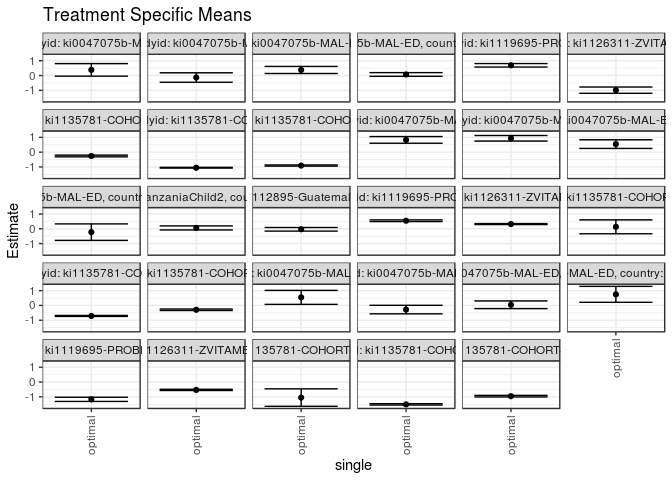

## Results Table

### Parameter: TSM

| agecat | studyid | country | intervention_level | baseline_level | estimate | ci_lower | ci_upper |
| --- | --- | --- | --- | --- | --- | --- | --- |
| Birth | ki0047075b-MAL-ED | BRAZIL | optimal | observed | 0.5431175 | 0.0713188 | 1.0149162 |
| Birth | ki0047075b-MAL-ED | PERU | optimal | observed | -0.2806276 | -0.5687278 | 0.0074726 |
| Birth | ki0047075b-MAL-ED | SOUTH AFRICA | optimal | observed | 0.0447024 | -0.2144075 | 0.3038123 |
| Birth | ki0047075b-MAL-ED | TANZANIA, UNITED REPUBLIC OF | optimal | observed | 0.7490353 | 0.2101930 | 1.2878776 |
| Birth | ki1119695-PROBIT | BELARUS | optimal | observed | -1.1672645 | -1.3098096 | -1.0247194 |
| Birth | ki1126311-ZVITAMBO | ZIMBABWE | optimal | observed | -0.5301780 | -0.5707453 | -0.4896107 |
| Birth | ki1135781-COHORTS | GUATEMALA | optimal | observed | -1.0480498 | -1.6380299 | -0.4580698 |
| Birth | ki1135781-COHORTS | INDIA | optimal | observed | -1.5086260 | -1.5534561 | -1.4637958 |
| Birth | ki1135781-COHORTS | PHILIPPINES | optimal | observed | -0.9537912 | -1.0063610 | -0.9012213 |
| 6 months | ki0047075b-MAL-ED | BRAZIL | optimal | observed | 0.8283237 | 0.6031334 | 1.0535140 |
| 6 months | ki0047075b-MAL-ED | PERU | optimal | observed | 0.9379705 | 0.7501763 | 1.1257647 |
| 6 months | ki0047075b-MAL-ED | SOUTH AFRICA | optimal | observed | 0.5435110 | 0.2524930 | 0.8345290 |
| 6 months | ki0047075b-MAL-ED | TANZANIA, UNITED REPUBLIC OF | optimal | observed | -0.2270500 | -0.7848357 | 0.3307357 |
| 6 months | ki1066203-TanzaniaChild2 | TANZANIA, UNITED REPUBLIC OF | optimal | observed | 0.0579821 | -0.0797550 | 0.1957192 |
| 6 months | ki1112895-Guatemala BSC | GUATEMALA | optimal | observed | -0.0336609 | -0.1549645 | 0.0876427 |
| 6 months | ki1119695-PROBIT | BELARUS | optimal | observed | 0.5440604 | 0.4879400 | 0.6001808 |
| 6 months | ki1126311-ZVITAMBO | ZIMBABWE | optimal | observed | 0.3186594 | 0.2848808 | 0.3524381 |
| 6 months | ki1135781-COHORTS | GUATEMALA | optimal | observed | 0.1332412 | -0.3366368 | 0.6031192 |
| 6 months | ki1135781-COHORTS | INDIA | optimal | observed | -0.7099000 | -0.7430338 | -0.6767662 |
| 6 months | ki1135781-COHORTS | PHILIPPINES | optimal | observed | -0.2935253 | -0.3437693 | -0.2432814 |
| 24 months | ki0047075b-MAL-ED | BRAZIL | optimal | observed | 0.3804856 | -0.0442005 | 0.8051717 |
| 24 months | ki0047075b-MAL-ED | PERU | optimal | observed | -0.1339248 | -0.4522180 | 0.1843685 |
| 24 months | ki0047075b-MAL-ED | SOUTH AFRICA | optimal | observed | 0.3762348 | 0.1368126 | 0.6156569 |
| 24 months | ki0047075b-MAL-ED | TANZANIA, UNITED REPUBLIC OF | optimal | observed | 0.0715059 | -0.0531563 | 0.1961682 |
| 24 months | ki1119695-PROBIT | BELARUS | optimal | observed | 0.6917362 | 0.5741777 | 0.8092946 |
| 24 months | ki1126311-ZVITAMBO | ZIMBABWE | optimal | observed | -0.9895301 | -1.2020688 | -0.7769914 |
| 24 months | ki1135781-COHORTS | GUATEMALA | optimal | observed | -0.2586237 | -0.3163983 | -0.2008490 |
| 24 months | ki1135781-COHORTS | INDIA | optimal | observed | -1.0535389 | -1.0784432 | -1.0286346 |
| 24 months | ki1135781-COHORTS | PHILIPPINES | optimal | observed | -0.9050567 | -0.9429475 | -0.8671659 |

### Parameter: E(Y)

| agecat | studyid | country | intervention_level | baseline_level | estimate | ci_lower | ci_upper |
| --- | --- | --- | --- | --- | --- | --- | --- |
| Birth | ki0047075b-MAL-ED | BRAZIL | observed | observed | 0.4038798 | 0.2296279 | 0.5781316 |
| Birth | ki0047075b-MAL-ED | PERU | observed | observed | -0.0735842 | -0.1836203 | 0.0364518 |
| Birth | ki0047075b-MAL-ED | SOUTH AFRICA | observed | observed | -0.0562791 | -0.2000837 | 0.0875255 |
| Birth | ki0047075b-MAL-ED | TANZANIA, UNITED REPUBLIC OF | observed | observed | 0.7932203 | 0.5962220 | 0.9902187 |
| Birth | ki1119695-PROBIT | BELARUS | observed | observed | -1.1463469 | -1.3562674 | -0.9364264 |
| Birth | ki1126311-ZVITAMBO | ZIMBABWE | observed | observed | -0.5145122 | -0.5404077 | -0.4886167 |
| Birth | ki1135781-COHORTS | GUATEMALA | observed | observed | -1.0552243 | -1.1617873 | -0.9486614 |
| Birth | ki1135781-COHORTS | INDIA | observed | observed | -0.9765068 | -1.0113301 | -0.9416835 |
| Birth | ki1135781-COHORTS | PHILIPPINES | observed | observed | -0.7377902 | -0.7844819 | -0.6910986 |
| 6 months | ki0047075b-MAL-ED | BRAZIL | observed | observed | 0.9717225 | 0.8073791 | 1.1360658 |
| 6 months | ki0047075b-MAL-ED | PERU | observed | observed | 1.0543956 | 0.9326967 | 1.1760945 |
| 6 months | ki0047075b-MAL-ED | SOUTH AFRICA | observed | observed | 0.5420735 | 0.3899459 | 0.6942011 |
| 6 months | ki0047075b-MAL-ED | TANZANIA, UNITED REPUBLIC OF | observed | observed | 0.5170513 | 0.3872178 | 0.6468847 |
| 6 months | ki1066203-TanzaniaChild2 | TANZANIA, UNITED REPUBLIC OF | observed | observed | 0.0797577 | 0.0268998 | 0.1326156 |
| 6 months | ki1112895-Guatemala BSC | GUATEMALA | observed | observed | -0.0568833 | -0.1722874 | 0.0585208 |
| 6 months | ki1119695-PROBIT | BELARUS | observed | observed | 0.5789633 | 0.5190130 | 0.6389137 |
| 6 months | ki1126311-ZVITAMBO | ZIMBABWE | observed | observed | 0.3050103 | 0.2788985 | 0.3311222 |
| 6 months | ki1135781-COHORTS | GUATEMALA | observed | observed | 0.1920134 | 0.1173734 | 0.2666534 |
| 6 months | ki1135781-COHORTS | INDIA | observed | observed | -0.7104795 | -0.7428008 | -0.6781581 |
| 6 months | ki1135781-COHORTS | PHILIPPINES | observed | observed | -0.2936948 | -0.3352840 | -0.2521057 |
| 24 months | ki0047075b-MAL-ED | BRAZIL | observed | observed | 0.4466272 | 0.2416144 | 0.6516401 |
| 24 months | ki0047075b-MAL-ED | PERU | observed | observed | 0.1199005 | -0.0000331 | 0.2398341 |
| 24 months | ki0047075b-MAL-ED | SOUTH AFRICA | observed | observed | 0.4267017 | 0.3074751 | 0.5459283 |
| 24 months | ki0047075b-MAL-ED | TANZANIA, UNITED REPUBLIC OF | observed | observed | 0.0500935 | -0.0748234 | 0.1750103 |
| 24 months | ki1119695-PROBIT | BELARUS | observed | observed | 0.6863435 | 0.5745700 | 0.7981170 |
| 24 months | ki1126311-ZVITAMBO | ZIMBABWE | observed | observed | -1.1781043 | -1.2781256 | -1.0780830 |
| 24 months | ki1135781-COHORTS | GUATEMALA | observed | observed | -0.2796964 | -0.3351582 | -0.2242346 |
| 24 months | ki1135781-COHORTS | INDIA | observed | observed | -0.6594122 | -0.6925753 | -0.6262491 |
| 24 months | ki1135781-COHORTS | PHILIPPINES | observed | observed | -0.6100579 | -0.6471813 | -0.5729344 |

### Parameter: PAR

| agecat | studyid | country | intervention_level | baseline_level | estimate | ci_lower | ci_upper |
| --- | --- | --- | --- | --- | --- | --- | --- |
| Birth | ki0047075b-MAL-ED | BRAZIL | optimal | observed | -0.1392377 | -0.5852491 | 0.3067737 |
| Birth | ki0047075b-MAL-ED | PERU | optimal | observed | 0.2070434 | -0.0616614 | 0.4757482 |
| Birth | ki0047075b-MAL-ED | SOUTH AFRICA | optimal | observed | -0.1009815 | -0.3111358 | 0.1091729 |
| Birth | ki0047075b-MAL-ED | TANZANIA, UNITED REPUBLIC OF | optimal | observed | 0.0441850 | -0.5065826 | 0.5949527 |
| Birth | ki1119695-PROBIT | BELARUS | optimal | observed | 0.0209176 | -0.1266027 | 0.1684379 |
| Birth | ki1126311-ZVITAMBO | ZIMBABWE | optimal | observed | 0.0156658 | -0.0151421 | 0.0464738 |
| Birth | ki1135781-COHORTS | GUATEMALA | optimal | observed | -0.0071745 | -0.5838936 | 0.5695447 |
| Birth | ki1135781-COHORTS | INDIA | optimal | observed | 0.5321191 | 0.4927812 | 0.5714570 |
| Birth | ki1135781-COHORTS | PHILIPPINES | optimal | observed | 0.2160010 | 0.1746593 | 0.2573426 |
| 6 months | ki0047075b-MAL-ED | BRAZIL | optimal | observed | 0.1433988 | 0.0024773 | 0.2843203 |
| 6 months | ki0047075b-MAL-ED | PERU | optimal | observed | 0.1164251 | -0.0406495 | 0.2734996 |
| 6 months | ki0047075b-MAL-ED | SOUTH AFRICA | optimal | observed | -0.0014375 | -0.2507801 | 0.2479051 |
| 6 months | ki0047075b-MAL-ED | TANZANIA, UNITED REPUBLIC OF | optimal | observed | 0.7441013 | 0.1939333 | 1.2942693 |
| 6 months | ki1066203-TanzaniaChild2 | TANZANIA, UNITED REPUBLIC OF | optimal | observed | 0.0217756 | -0.1030411 | 0.1465923 |
| 6 months | ki1112895-Guatemala BSC | GUATEMALA | optimal | observed | -0.0232224 | -0.0647178 | 0.0182731 |
| 6 months | ki1119695-PROBIT | BELARUS | optimal | observed | 0.0349030 | 0.0228389 | 0.0469670 |
| 6 months | ki1126311-ZVITAMBO | ZIMBABWE | optimal | observed | -0.0136491 | -0.0353195 | 0.0080212 |
| 6 months | ki1135781-COHORTS | GUATEMALA | optimal | observed | 0.0587722 | -0.3977769 | 0.5153213 |
| 6 months | ki1135781-COHORTS | INDIA | optimal | observed | -0.0005794 | -0.0018941 | 0.0007352 |
| 6 months | ki1135781-COHORTS | PHILIPPINES | optimal | observed | -0.0001695 | -0.0262706 | 0.0259316 |
| 24 months | ki0047075b-MAL-ED | BRAZIL | optimal | observed | 0.0661416 | -0.3314376 | 0.4637207 |
| 24 months | ki0047075b-MAL-ED | PERU | optimal | observed | 0.2538253 | -0.0278886 | 0.5355391 |
| 24 months | ki0047075b-MAL-ED | SOUTH AFRICA | optimal | observed | 0.0504669 | -0.1444228 | 0.2453566 |
| 24 months | ki0047075b-MAL-ED | TANZANIA, UNITED REPUBLIC OF | optimal | observed | -0.0214125 | -0.0524160 | 0.0095911 |
| 24 months | ki1119695-PROBIT | BELARUS | optimal | observed | -0.0053927 | -0.0208196 | 0.0100342 |
| 24 months | ki1126311-ZVITAMBO | ZIMBABWE | optimal | observed | -0.1885742 | -0.4033520 | 0.0262037 |
| 24 months | ki1135781-COHORTS | GUATEMALA | optimal | observed | -0.0210727 | -0.0438266 | 0.0016812 |
| 24 months | ki1135781-COHORTS | INDIA | optimal | observed | 0.3941267 | 0.3592306 | 0.4290227 |
| 24 months | ki1135781-COHORTS | PHILIPPINES | optimal | observed | 0.2949988 | 0.2555952 | 0.3344025 |